# Fault localization experiments in Python

Mohammad Rezaalipour and Carlo A. Furia

# 1 Data input

Let’s start with reading the computed metrics for all projects.

```
## [1] TRUE
```

```
## 'data.frame':    2541 obs. of  15 variables:
##  $ project    : Factor w/ 12 levels "black","cookiecutter",..: 1 1 1 1 1 1 1 1 1 1 ...
##  $ bug_number : int  1 3 4 6 7 8 10 11 14 15 ...
##  $ granularity: Factor w/ 3 levels "function","statement",..: 1 1 1 1 1 1 1 1 1 1 ...
##  $ technique  : Factor w/ 7 levels "DStar","Metallaxis",..: 7 7 7 7 7 7 7 7 7 7 ...
##  $ crashing   : int  0 0 0 0 0 0 0 0 1 0 ...
##  $ predicate  : int  0 0 0 1 1 1 1 1 1 1 ...
##  $ time       : num  132.4 104.2 68.5 58.8 64.8 ...
##  $ einspect   : num  4 100.5 39.5 11 29 ...
##  $ exam       : num  0.0099 0.3018 0.1282 0.0364 0.0967 ...
##  $ cdist      : num  NA NA NA NA NA NA NA NA NA NA ...
##  $ svcomp     : num  NA NA NA NA NA NA NA NA NA NA ...
##  $ minutes    : num  2.21 1.74 1.14 0.98 1.08 ...
##  $ family     : Factor w/ 4 levels "MBFL","PS","ST",..: 4 4 4 4 4 4 4 4 4 4 ...
##  $ category   : Factor w/ 4 levels "CL","DEV","DS",..: 2 2 2 2 2 2 2 2 2 2 ...
##  $ bugid      : Factor w/ 121 levels "black1","black10",..: 1 9 10 11 12 13 2 3 4 5 ...
```

We have a total of 12 projects, which we can classify by category:

- Data science (`ds`): `spacy`, `keras`, `pandas`
- Developer tools (`dev`): `cookiecutter`, `black`
- Web tools (`web`): `sanic`, `fastapi`, `tornado`
- Command line tools (`cl`): `httpie`, `thefuck`, `tqdm`, `youtubedl`

# 2 Pairwise comparisons

Let’s see an example of visual and statistical comparison of two groups of experiments for the same bugs.

To make the example concrete, let’s pick two groups and compare their $E_{\text{inspect}}$ scores on statement-level fault localization:

- $S$ are the experiments done with any SBFL technique
- $M$ are the experiments done with any MBFL technique

Since there are three experiments per bug using SBFL, but only two experiments per bug using MBFL, we’ll aggregate scores for the same bug by average.

Let’s start with some visualization: a scatterplot with a point for each bug; each point has coordinates $x, y$ where $x$ is its score in MBFL and $y$ its score in SBFL.

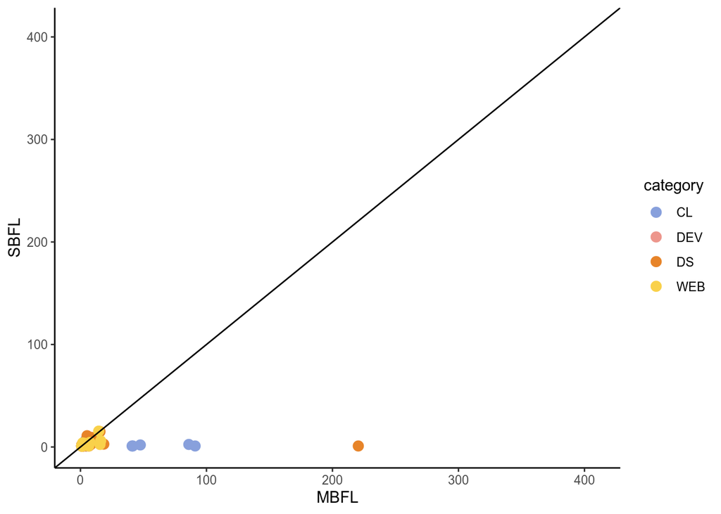

As you can see, there are a bulk of bugs for which SBFL performs very similarly to MBFL (points close to the $x = y$ straight line). However, for several other bugs, SBFL is much better (remember that lower is better for this score).

Looking at the colors, we notice that several bugs in the CL (and possibly DS) category are overrepresented among the “harder” bugs on which SBFL behaves much better than MBFL.

Analyzing the same data numerically, we can compute the correlation (Kendall’s $\tau$) between $S$ and $M$:

```
##
##  Kendall's rank correlation tau
##
## data:  S and M
## z = 7.5808, p-value = 3.434e-14
## alternative hypothesis: true tau is not equal to 0
## sample estimates:
##       tau
## 0.5522076
```

Finally, we may also perform a statistical test (Wilcoxon’s paired test) and compute a matching effect size (Cliff’s delta).

```
##
##  Wilcoxon signed rank test with continuity correction
##
## data:  S and M
## V = 1881, p-value = 7.549e-06
## alternative hypothesis: true location shift is not equal to 0
```

```
##
## Cliff's Delta
##
## delta estimate: -0.3992897 (medium)
## 95 percent confidence interval:
##      lower      upper
## -0.5222158 -0.2601092
```

These statistics, for what they’re worth, seem to confirm that there is a noticeable difference in favor of SBFL.

Now, let’s generalize this to a scatterplot matrix to show the relations between all possible pairs of FL families.

First, we define a bunch of helper functions.

Then, we use them to generate plots for $E$.

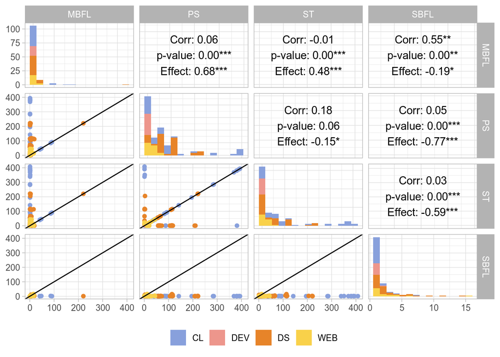

Now, it’s easy to compute a similar plot for other metrics. For example, running time (in minutes):

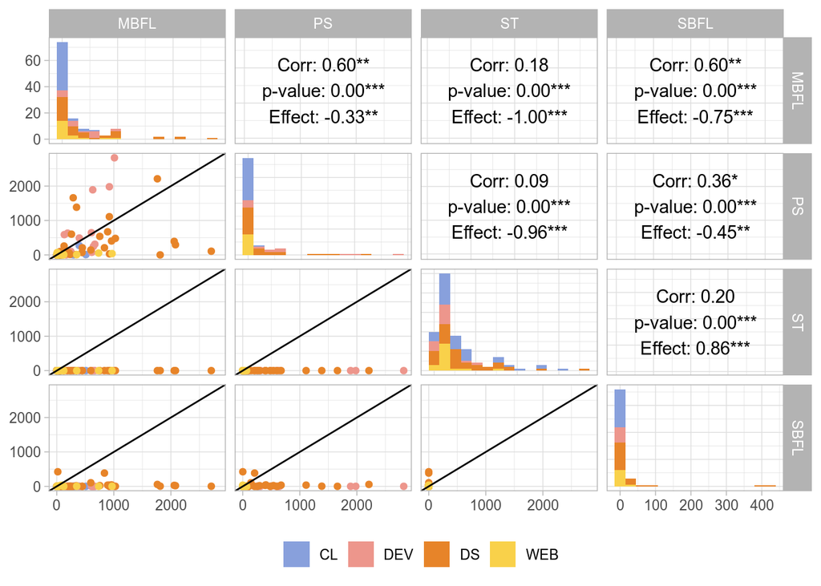

# 3 Regression models

Let’s build a simple multivariate regression model, where we predict `einspect` and `time` from bug and technique.

First, we standardize the predictors, so that it’s much easier to set sensible priors.

## 3.1 Model $m_1$

Here’s a basic regression model, where the only unusual aspects are that it’s multivariate, and log-transforms the mean (since both outcome variables must be nonnegative).

## 3.2 Fitting $m_1$

Let’s do the usual checks to make sure that everything is fine with the fitting.

Prior checks, confirming that the sampled priors span a wide range of values, amply including the data.

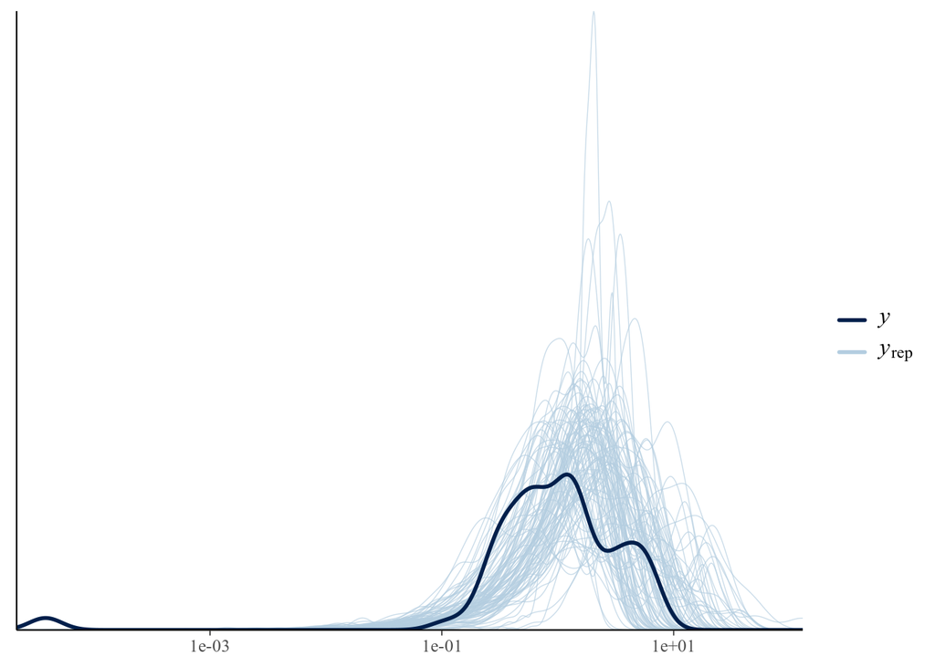

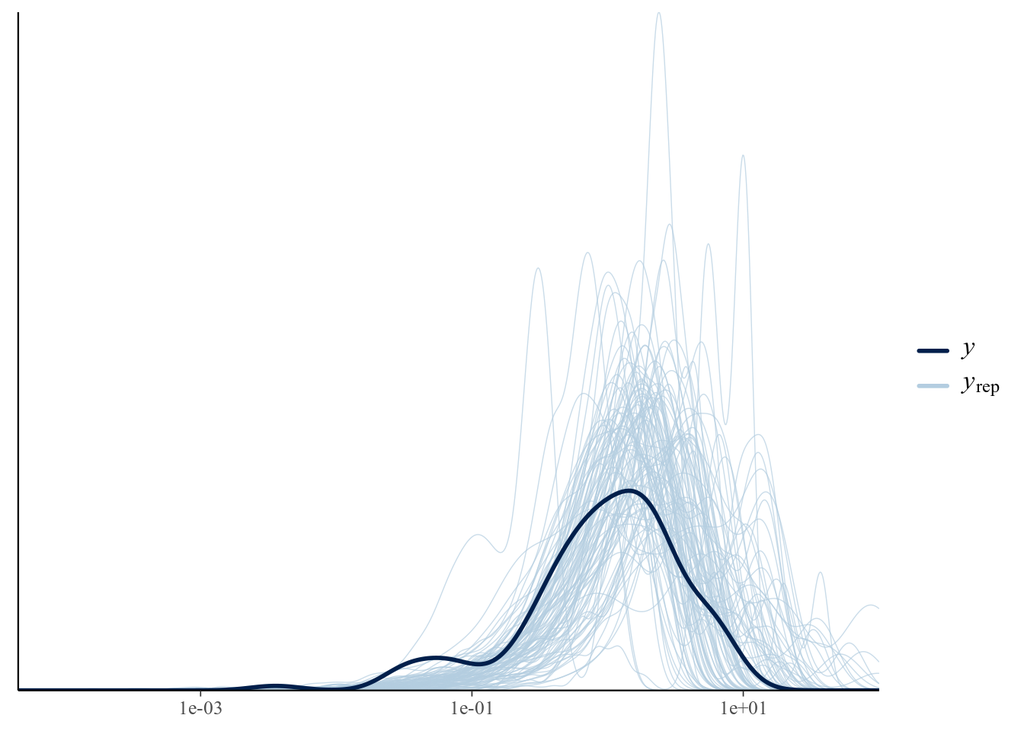

Now we fit the actual model.

```
## Running MCMC with 4 chains, at most 8 in parallel...
##
## Chain 1 finished in 14.0 seconds.
## Chain 3 finished in 14.5 seconds.
## Chain 2 finished in 14.7 seconds.
## Chain 4 finished in 15.0 seconds.
##
## All 4 chains finished successfully.
## Mean chain execution time: 14.5 seconds.
## Total execution time: 15.3 seconds.
```

Next, we check the usual diagnostics:

- No (or at most a few) divergent transitions
- $\widehat{R}$ ratio below $1.01$
- Effective sample size (ESS), as a ratio of the total sample size, at least 10%

```
## [1] 0
```

```
## [1] 1.003001
```

```
## [1] 0.3625303
```

Finally, we check the posteriors, to ensure that we have a decent approximation of the data.

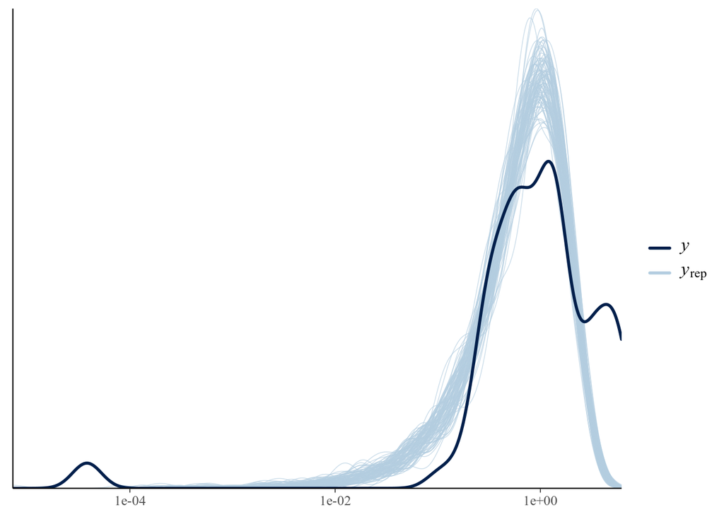

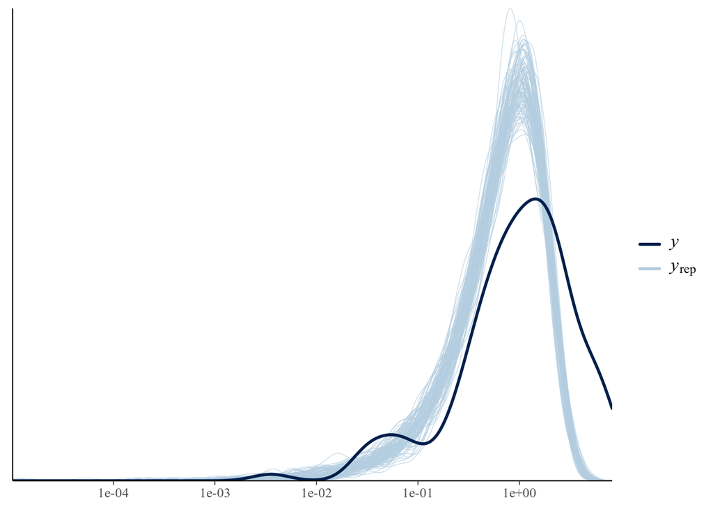

As you can see, the simulated posteriors are acceptable given that the data is complex, whereas the model is quite simple.

## 3.3 Analyzing $m_1$

```
##  Family: MV(gaussian, gaussian)
##   Links: mu = log; sigma = identity
##          mu = log; sigma = identity
## Formula: einspectS ~ 0 + family + category
##          timeS ~ 0 + family + category
##    Data: by.statement (Number of observations: 847)
##   Draws: 4 chains, each with iter = 2000; warmup = 1000; thin = 1;
##          total post-warmup draws = 4000
##
## Population-Level Effects:
##                       Estimate Est.Error l-95% CI u-95% CI Rhat Bulk_ESS
## einspectS_familyMBFL     -2.93      0.50    -4.00    -2.06 1.00     5289
## einspectS_familyPS        0.39      0.08     0.22     0.54 1.00     4980
## einspectS_familyST        0.43      0.09     0.24     0.59 1.00     3941
## einspectS_familySBFL     -3.42      0.49    -4.47    -2.55 1.00     4642
## einspectS_categoryDEV    -2.58      0.51    -3.71    -1.68 1.00     4856
## einspectS_categoryDS     -0.71      0.14    -1.00    -0.45 1.00     3896
## einspectS_categoryWEB    -2.38      0.50    -3.48    -1.53 1.00     4703
## timeS_familyMBFL         -1.46      0.21    -1.87    -1.07 1.00     1450
## timeS_familyPS           -1.92      0.25    -2.44    -1.45 1.00     2025
## timeS_familyST           -3.80      0.46    -4.75    -2.98 1.00     3188
## timeS_familySBFL         -4.39      0.43    -5.27    -3.60 1.00     2978
## timeS_categoryDEV         1.41      0.26     0.91     1.90 1.00     1845
## timeS_categoryDS          1.50      0.21     1.10     1.93 1.00     1483
## timeS_categoryWEB        -1.00      0.66    -2.42     0.12 1.00     4419
##                       Tail_ESS
## einspectS_familyMBFL      2899
## einspectS_familyPS        2837
## einspectS_familyST        2732
## einspectS_familySBFL      2555
## einspectS_categoryDEV     2771
## einspectS_categoryDS      3251
## einspectS_categoryWEB     2519
## timeS_familyMBFL          1934
## timeS_familyPS            2401
## timeS_familyST            2367
## timeS_familySBFL          2831
## timeS_categoryDEV         2308
## timeS_categoryDS          1987
## timeS_categoryWEB         2572
##
## Family Specific Parameters:
##                 Estimate Est.Error l-95% CI u-95% CI Rhat Bulk_ESS Tail_ESS
## sigma_einspectS     0.86      0.02     0.82     0.90 1.00     4691     3298
## sigma_timeS         0.92      0.02     0.87     0.96 1.00     4341     2792
##
## Residual Correlations:
##                         Estimate Est.Error l-95% CI u-95% CI Rhat Bulk_ESS
## rescor(einspectS,timeS)     0.08      0.04     0.01     0.15 1.00     4762
##                         Tail_ESS
## rescor(einspectS,timeS)     2857
##
## Draws were sampled using sample(hmc). For each parameter, Bulk_ESS
## and Tail_ESS are effective sample size measures, and Rhat is the potential
## scale reduction factor on split chains (at convergence, Rhat = 1).
```

What’s noticeable here is some non-negligible residual correlation between the two outcomes `einspect` and `time`, which means that there is a dependency between these two variables that is not captured by the model.

Let’s set up some functions to analyze the posterior samples of `m1` (and similar models).

Let’s use these functions to first analyze the effects per *family* of FL techniques.

| prob | MBFL | PS | SBFL | ST |
| --- | --- | --- | --- | --- |
| \|0.5 | -1.7292609 | 1.725218 | -2.2900809 | 1.754296 |
| \|0.7 | -2.0029509 | 1.697425 | -2.4727709 | 1.722402 |
| \|0.9 | -2.3148409 | 1.634571 | -2.8150009 | 1.662327 |
| \|0.95 | -2.5507209 | 1.611522 | -3.0687809 | 1.649788 |
| \|0.99 | -3.0006709 | 1.540838 | -3.3542209 | 1.582624 |
| 0.99\| | -0.4336509 | 1.968382 | -0.8256209 | 2.023430 |
| 0.95\| | -0.6437809 | 1.928568 | -1.1666309 | 1.988130 |
| 0.9\| | -0.7022909 | 1.901841 | -1.2244209 | 1.944407 |
| 0.7\| | -0.9791509 | 1.864047 | -1.4949609 | 1.899456 |
| 0.5\| | -1.0808309 | 1.832090 | -1.6701309 | 1.871154 |

| prob | MBFL | PS | SBFL | ST |
| --- | --- | --- | --- | --- |
| \|0.5 | 1.3159617 | 0.7791817 | -1.7078983 | -1.08666834 |
| \|0.7 | 1.2103517 | 0.7076217 | -1.8982183 | -1.33700834 |
| \|0.9 | 1.1004817 | 0.5682317 | -2.1970183 | -1.65810834 |
| \|0.95 | 1.0241317 | 0.4835517 | -2.3400383 | -1.76071834 |
| \|0.99 | 0.8803617 | 0.3097017 | -2.6651683 | -2.16708834 |
| 0.99\| | 1.9138167 | 1.5518817 | -0.4493883 | 0.19127166 |
| 0.95\| | 1.8222117 | 1.4606717 | -0.6883583 | -0.01928834 |
| 0.9\| | 1.7801017 | 1.3884217 | -0.8101283 | -0.17559834 |
| 0.7\| | 1.6416417 | 1.2309917 | -1.0399683 | -0.40553834 |
| 0.5\| | 1.5991117 | 1.1222717 | -1.1517183 | -0.48038834 |

Looking at the effects by category of project does not yeld as strong differences, but we can see that `ds` projects tend to be associated with worse `e_inspect`, and that `web` projects are assocaited with shorter running times.

| prob | DEV | DS | WEB |
| --- | --- | --- | --- |
| \|0.5 | -0.88705824 | 1.0983198 | -0.7549782 |
| \|0.7 | -1.06522824 | 1.0695268 | -0.8814082 |
| \|0.9 | -1.50567824 | 0.9477838 | -1.2992182 |
| \|0.95 | -1.70550824 | 0.8847718 | -1.5018182 |
| \|0.99 | -2.10344824 | 0.7957518 | -1.9372382 |
| 0.99\| | 0.48108176 | 1.5231608 | 0.5881518 |
| 0.95\| | 0.30108176 | 1.4340808 | 0.4016418 |
| 0.9\| | 0.14196176 | 1.4117848 | 0.3287418 |
| 0.7\| | -0.02581824 | 1.3580798 | 0.1235118 |
| 0.5\| | -0.22345824 | 1.2847528 | -0.1123282 |

| prob | DEV | DS | WEB |
| --- | --- | --- | --- |
| \|0.5 | 0.6057051 | 0.7200851 | -1.9101249 |
| \|0.7 | 0.5231951 | 0.6422151 | -2.1513449 |
| \|0.9 | 0.3604331 | 0.5411351 | -2.7635249 |
| \|0.95 | 0.2703771 | 0.4748951 | -2.9685949 |
| \|0.99 | 0.1377891 | 0.3324931 | -3.4161649 |
| 0.99\| | 1.4345651 | 1.4214051 | -0.1157819 |
| 0.95\| | 1.2626551 | 1.2943751 | -0.4432219 |
| 0.9\| | 1.1952351 | 1.2373051 | -0.6401274 |
| 0.7\| | 1.0541251 | 1.0851151 | -0.8100329 |
| 0.5\| | 0.9529751 | 1.0104851 | -1.0418689 |

## 3.4 Model $m_2$

Let’s make the model more sophisticated, with varying effects, and modeling these effects as [possibly correlated](https://cran.r-project.org/web/packages/brms/vignettes/brms_multivariate.html) (which makes sense, since we have two model parts)

## 3.5 Fitting $m_2$

Let’s fit $m_2$ and check the fit.

Prior checks:

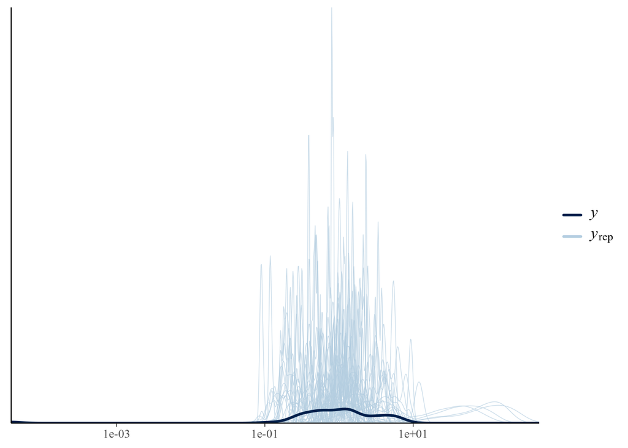

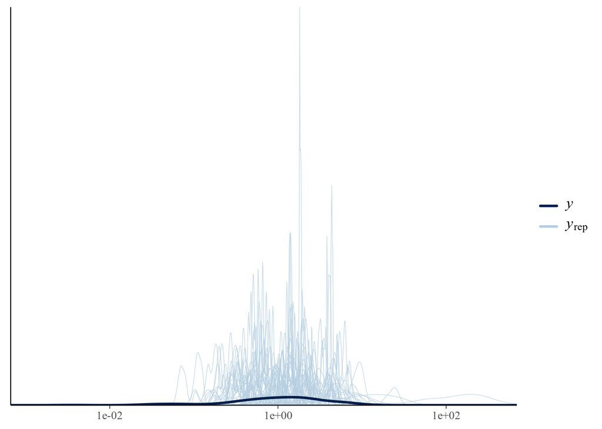

We fit model $m_2$.

```
## Running MCMC with 4 chains, at most 8 in parallel...
##
## Chain 3 finished in 45.5 seconds.
## Chain 4 finished in 45.9 seconds.
## Chain 1 finished in 47.3 seconds.
## Chain 2 finished in 48.8 seconds.
##
## All 4 chains finished successfully.
## Mean chain execution time: 46.9 seconds.
## Total execution time: 48.9 seconds.
```

Diagnostics:

```
## [1] 0
```

```
## [1] 1.002176
```

```
## [1] 0.3855776
```

Posterior checks:

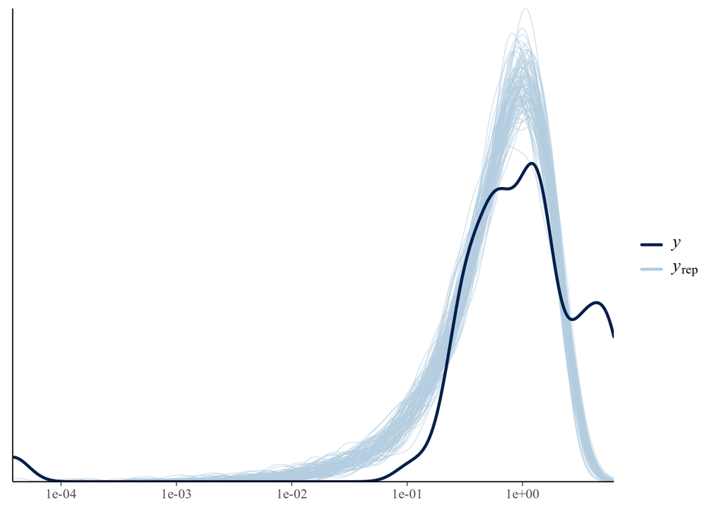

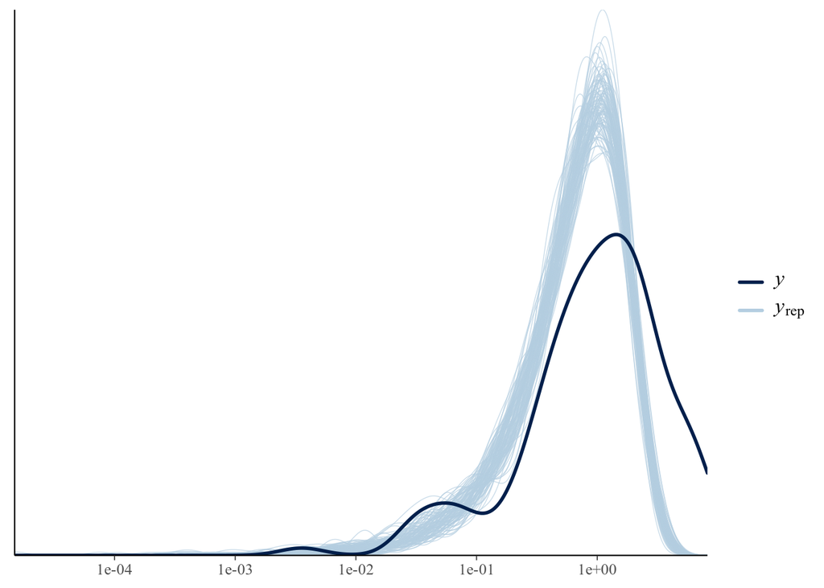

We don’t notice a clear improvement compared to $m_1$. Let’s compare the two models using LOO.

```
## Output of model 'm1':
##
## Computed from 4000 by 847 log-likelihood matrix
##
##          Estimate    SE
## elpd_loo  -2220.7  89.0
## p_loo        44.9   7.4
## looic      4441.3 177.9
## ------
## Monte Carlo SE of elpd_loo is NA.
##
## Pareto k diagnostic values:
##                          Count Pct.    Min. n_eff
## (-Inf, 0.5]   (good)     844   99.6%   684
##  (0.5, 0.7]   (ok)         2    0.2%   212
##    (0.7, 1]   (bad)        1    0.1%   60
##    (1, Inf)   (very bad)   0    0.0%   <NA>
## See help('pareto-k-diagnostic') for details.
##
## Output of model 'm2':
##
## Computed from 4000 by 847 log-likelihood matrix
##
##          Estimate    SE
## elpd_loo  -2215.1  90.4
## p_loo        47.3   8.2
## looic      4430.2 180.9
## ------
## Monte Carlo SE of elpd_loo is NA.
##
## Pareto k diagnostic values:
##                          Count Pct.    Min. n_eff
## (-Inf, 0.5]   (good)     845   99.8%   295
##  (0.5, 0.7]   (ok)         0    0.0%   <NA>
##    (0.7, 1]   (bad)        2    0.2%   21
##    (1, Inf)   (very bad)   0    0.0%   <NA>
## See help('pareto-k-diagnostic') for details.
##
## Model comparisons:
##    elpd_diff se_diff
## m2  0.0       0.0
## m1 -5.5       2.3
```

$m_1$’s score is around 2.4 standard deviations worse than $m_2$’s, which is a non-negligible (albeit not strong) difference in favor of $m_2$ in terms of predictive capabilities.

## 3.6 Analyzing $m_2$

```
##  Family: MV(gaussian, gaussian)
##   Links: mu = log; sigma = identity
##          mu = log; sigma = identity
## Formula: einspectS ~ 1 + (1 | p | family) + (1 | q | category)
##          timeS ~ 1 + (1 | p | family) + (1 | q | category)
##    Data: by.statement (Number of observations: 847)
##   Draws: 4 chains, each with iter = 2000; warmup = 1000; thin = 1;
##          total post-warmup draws = 4000
##
## Group-Level Effects:
## ~category (Number of levels: 4)
##                                          Estimate Est.Error l-95% CI u-95% CI
## sd(einspectS_Intercept)                      0.66      0.12     0.44     0.92
## sd(timeS_Intercept)                          0.69      0.12     0.46     0.94
## cor(einspectS_Intercept,timeS_Intercept)    -0.18      0.23    -0.59     0.28
##                                          Rhat Bulk_ESS Tail_ESS
## sd(einspectS_Intercept)                  1.00     2959     2923
## sd(timeS_Intercept)                      1.00     3815     2793
## cor(einspectS_Intercept,timeS_Intercept) 1.00     2555     2554
##
## ~family (Number of levels: 4)
##                                          Estimate Est.Error l-95% CI u-95% CI
## sd(einspectS_Intercept)                      0.90      0.12     0.68     1.15
## sd(timeS_Intercept)                          0.77      0.12     0.55     1.03
## cor(einspectS_Intercept,timeS_Intercept)     0.06      0.20    -0.33     0.44
##                                          Rhat Bulk_ESS Tail_ESS
## sd(einspectS_Intercept)                  1.00     3198     3161
## sd(timeS_Intercept)                      1.00     3228     3120
## cor(einspectS_Intercept,timeS_Intercept) 1.00     2098     2186
##
## Population-Level Effects:
##                     Estimate Est.Error l-95% CI u-95% CI Rhat Bulk_ESS Tail_ESS
## einspectS_Intercept    -2.12      0.52    -3.12    -1.06 1.00     1590     2090
## timeS_Intercept        -2.10      0.50    -3.07    -1.12 1.00     1819     2463
##
## Family Specific Parameters:
##                 Estimate Est.Error l-95% CI u-95% CI Rhat Bulk_ESS Tail_ESS
## sigma_einspectS     0.86      0.02     0.82     0.90 1.00     4743     2993
## sigma_timeS         0.91      0.02     0.87     0.96 1.00     5225     2896
##
## Residual Correlations:
##                         Estimate Est.Error l-95% CI u-95% CI Rhat Bulk_ESS
## rescor(einspectS,timeS)     0.07      0.04     0.00     0.14 1.00     4868
##                         Tail_ESS
## rescor(einspectS,timeS)     2767
##
## Draws were sampled using sample(hmc). For each parameter, Bulk_ESS
## and Tail_ESS are effective sample size measures, and Rhat is the potential
## scale reduction factor on split chains (at convergence, Rhat = 1).
```

Let’s now perform an effects analysis on the fitted coefficients of `m2`. First we introduce a summary function.

Then we use the functions to analyze the effects of the FL techniques.

```
## $ints
##             MBFL         PS         ST      SBFL
## |0.5  -2.4458475 1.05462500 1.09144000 -2.960513
## |0.7  -2.7122600 0.87829785 0.92771120 -3.208714
## |0.9  -3.1532725 0.58428570 0.62392390 -3.638860
## |0.95 -3.3991242 0.39282643 0.46487145 -3.882049
## |0.99 -3.9058717 0.06367159 0.09330464 -4.415057
## 0.99| -0.6154573 2.47393375 2.47274470 -1.045117
## 0.95| -0.9022452 2.23034550 2.26601650 -1.357288
## 0.9|  -1.0456720 2.10174150 2.15423050 -1.542160
## 0.7|  -1.3951635 1.84201750 1.89048100 -1.871093
## 0.5|  -1.5896675 1.67474500 1.71992500 -2.071522
##
## $est
##      MBFL        PS        ST      SBFL
## -2.042826  1.354797  1.399998 -2.532691
```

```
## $ints
##            MBFL          PS          ST       SBFL
## |0.5  0.9676170  0.42415425 -1.75544250 -2.3454750
## |0.7  0.8102580  0.25800190 -1.99937600 -2.5672915
## |0.9  0.5651526 -0.01689487 -2.39602450 -3.0386165
## |0.95 0.4383077 -0.15392192 -2.61059075 -3.3049487
## |0.99 0.2154951 -0.43942018 -3.19265165 -3.9566579
## 0.99| 2.3319310  1.84013025 -0.07693451 -0.5814263
## 0.95| 2.0882253  1.57176775 -0.34913012 -0.8821248
## 0.9|  1.9313755  1.42917050 -0.50588880 -1.0234990
## 0.7|  1.6738505  1.16831000 -0.82347985 -1.3463875
## 0.5|  1.5282525  1.02040500 -0.99340625 -1.5422750
##
## $est
##      MBFL        PS        ST      SBFL
## -2.042826  1.354797  1.399998 -2.532691
```

The results for `einspect` are clearer than with the simpler model, whereas the relation between running time and family `ps` weakens.

Let’s see what happens for the bug/category of projects.

```
## $ints
##              CL         DEV          DS        WEB
## |0.5  0.9087785 -1.61880750  0.14341425 -1.3454850
## |0.7  0.7742947 -1.80610750  0.02015701 -1.5612935
## |0.9  0.5550343 -2.19288000 -0.23080720 -1.9608855
## |0.95 0.3998676 -2.40792375 -0.36329695 -2.1459712
## |0.99 0.1103777 -2.83487475 -0.61407716 -2.4988289
## 0.99| 2.1121827 -0.07912062  1.42568520  0.1628556
## 0.95| 1.8573258 -0.40282340  1.11908150 -0.1215192
## 0.9|  1.7337395 -0.54345375  1.01290600 -0.2653025
## 0.7|  1.5036670 -0.79465315  0.76916035 -0.5252138
## 0.5|  1.3720475 -0.95640950  0.63276300 -0.6817105
##
## $est
##         CL        DEV         DS        WEB
##  1.1375599 -1.3033261  0.3880117 -1.0349807
```

```
## $ints
##               CL         DEV          DS         WEB
## |0.5  -1.9870200  0.55570550  0.67400725 -1.21489250
## |0.7  -2.2009200  0.42299760  0.53939980 -1.40920150
## |0.9  -2.5651945  0.19379920  0.32117100 -1.78392300
## |0.95 -2.7508743  0.06638743  0.18860810 -1.98440725
## |0.99 -3.2214357 -0.24324098 -0.05414875 -2.43393400
## 0.99| -0.5064634  1.79249200  1.82066600  0.28697062
## 0.95| -0.7529114  1.54579800  1.63630550  0.05166029
## 0.9|  -0.8766826  1.43347600  1.51935450 -0.11072715
## 0.7|  -1.1433530  1.20034800  1.28824350 -0.39034875
## 0.5|  -1.3055100  1.06316250  1.15486000 -0.54868100
##
## $est
##         CL        DEV         DS        WEB
##  1.1375599 -1.3033261  0.3880117 -1.0349807
```